# ggplotAnswers

*A1. Make a scatterplot between the Petal Length and Petal Width*

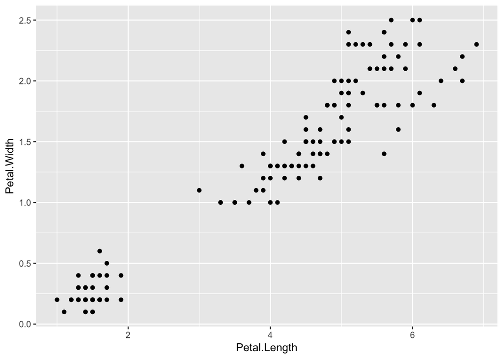

*A2. Make a histogram of the Sepal length*

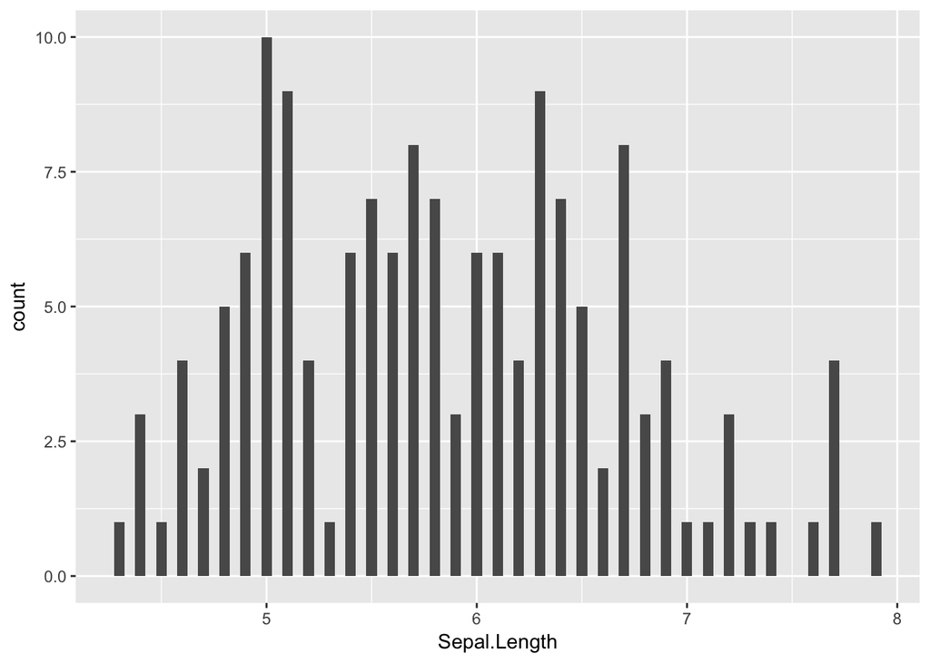

*A3. Make a boxplot of the Sepal width*

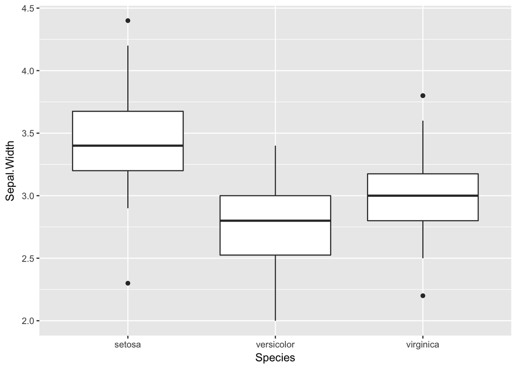

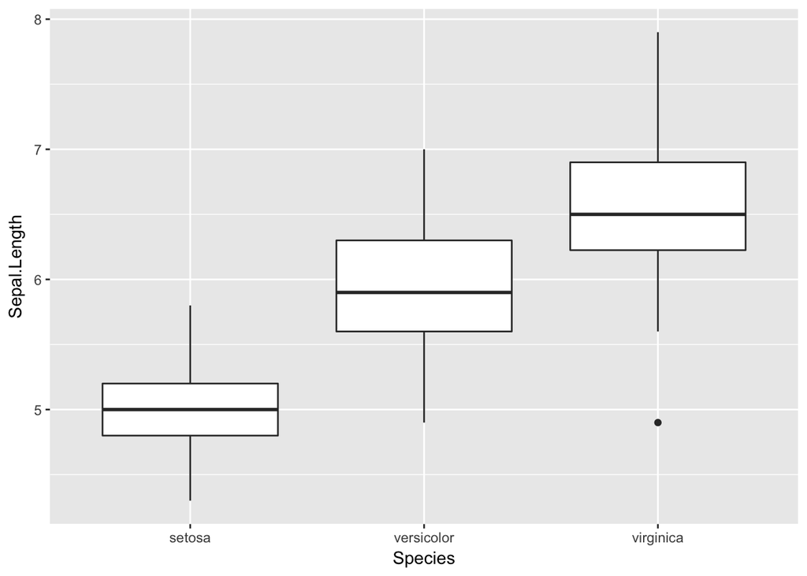

**A5. Plot boxplot + mean for Sepal width**

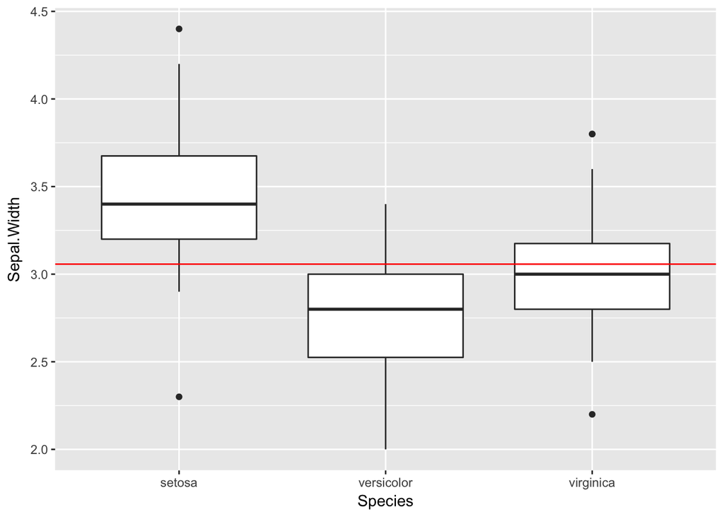

**A6. Run a t-test to determine the difference in means of sepal length between *Iris virginica* and *Iris versicolor*, and store the p-value in a variable called t.test.p.value**

```r
t.test.p.value
```

```
## [1] 1.866144e-07
```

*A7. Put the text in the lower right corner*

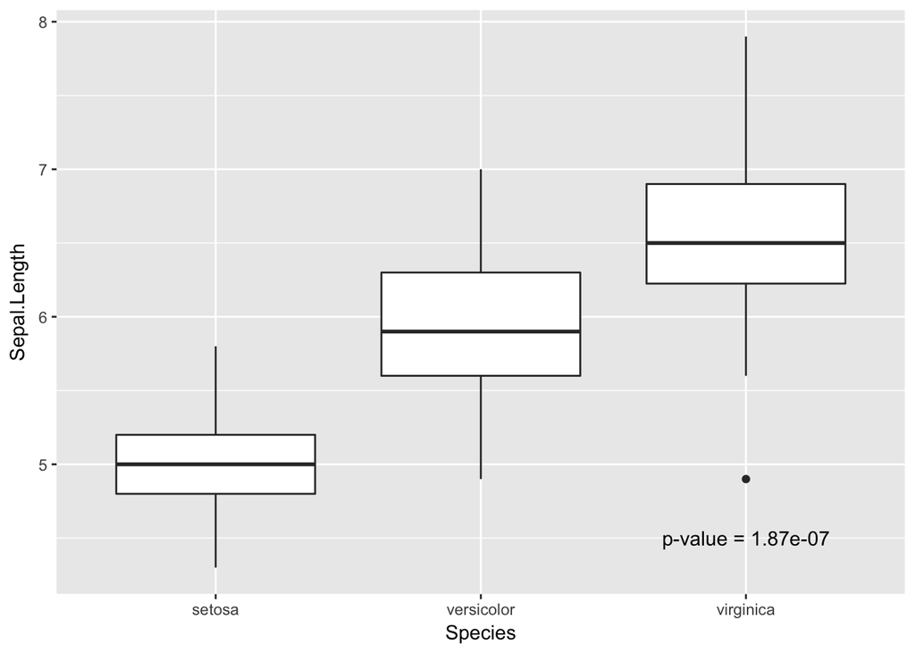

*A8. Recreate the colored boxplot above so that the points lay on top of the boxplot.*

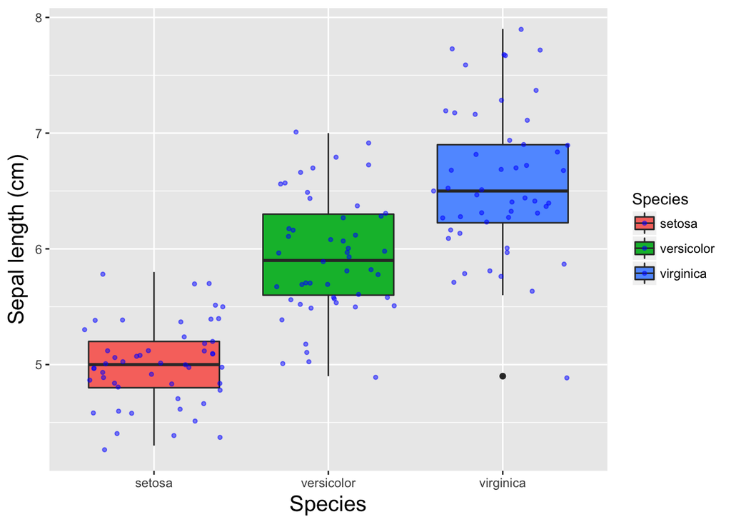

**A9. Use the facet_grid() function so that that the boxplots are grouped by the measured variables like the plot below**

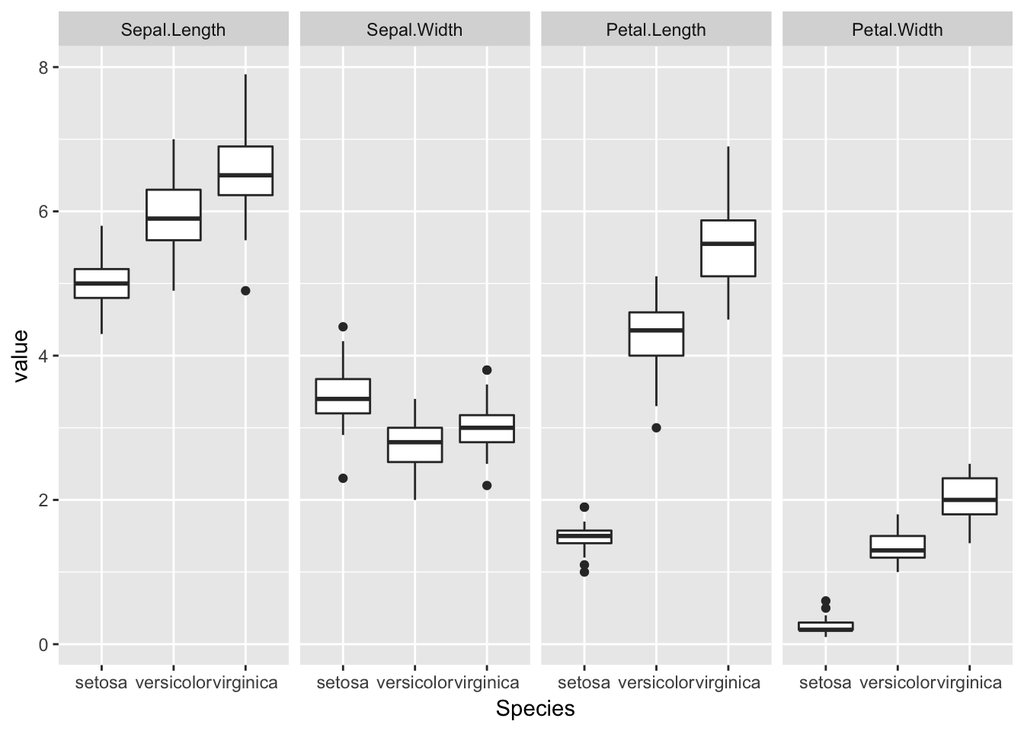

*A10. Use the geom_violin() function to create a similar plot like the last boxplot, grouped by the measured variables. Also, color the boxes by species and draw actual data points on top of the violin plot*

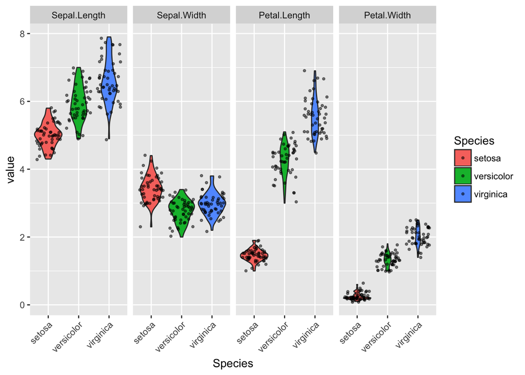

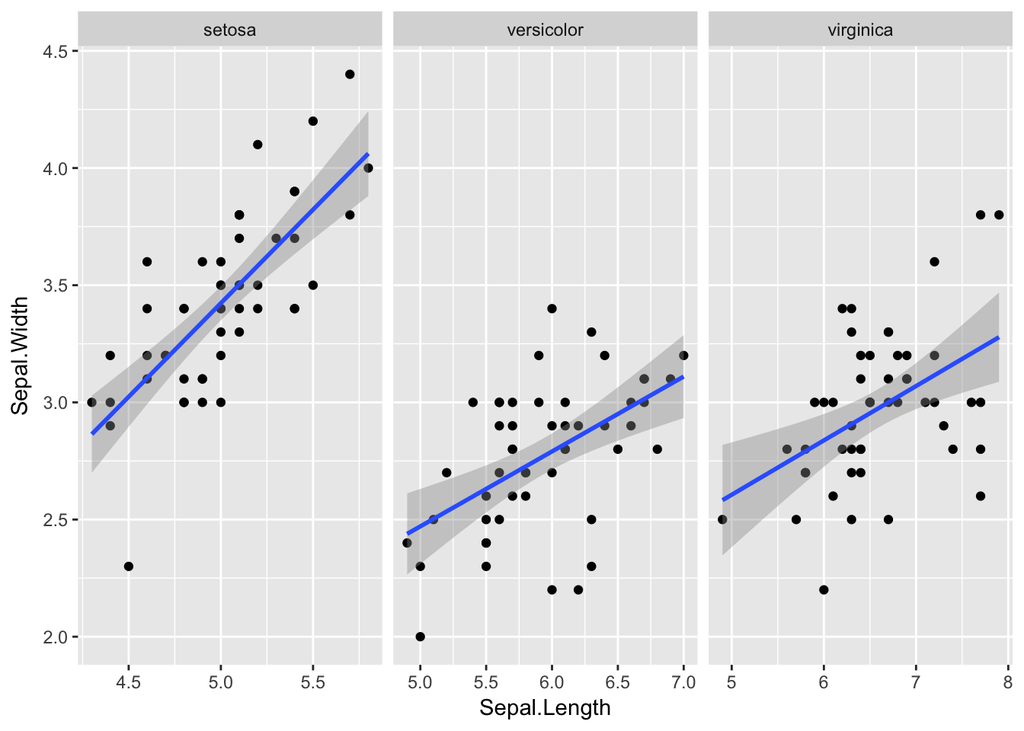